# Guided Tour of NIMBLE

NIMBLE 2022 virtual EFI workshop

NIMBLE Development Team

April 2022

# Workshop organization

- Today’s modules
- 1. Overview of `nimble`, intro to Hidden Markov models, fitting a dynamic occypancy model.
- 2. `nimbleEcology` distributions for capture-recapture, occupancy, dynamic occupancy
- Bonus modules
- 1. CJS capture-recapture model with dipper data
- 2. Extending models and methods using `nimbleFunction`s for efficiency and generality.
- 3. Speeding up spatial capture-recapture (`nimbleSCR`).

# What Is NIMBLE?

- **N**umerical **I**nference for statistical **M**odels using **B**ayesian and **L**ikelihood **E**stimation.
- A framework for hierarchical statistical models and methods.
- A nearly drop-in alternative to WinBUGS, OpenBUGS and JAGS.
- An extension of the BUGS language for:
  - writing new functions and distributions.
  - named alternative parameterizations (e.g. sd vs precision for `dnorm`).
  - Additional R-like coding, including vectorized declarations.
- A configurable system for MCMC.
- A library of other methods.
  - Sequential Monte Carlo (particle filtering)
  - Particle MCMC
  - Monte Carlo Expectation Maximization (maximum likelihood)
  - Reversible jump MCMC for variable selection
  - Special components for Conditional Auto-Regressive (CAR) models (spatial) and Bayesian non-parametric distributions (BNP).
- A model-generic programming system to write new analysis methods using two-stage `nimbleFunction`s.

# Assumptions for this workshop

- You are familiar with the BUGS/JAGS model language.
- You are familiar with occupancy statistical models
- The emphasis of this workshop is on the `nimble` and`nimbleEcology`

## Hidden Markov models (Intro)

Hidden Markov models (HMMs) are a general statistical framework for:

- systems with discrete latent states (usually) and discrete time steps
  - probabilities of transitioning between states at each time step
- discrete observation categories and imperfect observation
  - probabilities of being observed in one category given the (true) latent state.
- If transition and/or observation probabilities are time-dependent, we call it a “Dynamic HMM” (DHMM).

# Hidden Markov models in site occupancy models

- latent states are the presence or absence of a species at discrete spatial locations
- observed states are imperfect because the probability of detection != 1
- repeat samples at a spatial location enable the estimate of the latent states

# HMM example: Single species, multi season (“dynamic”) occupancy model

- Uses data simulations from Kery and Schaub [Bayesian Population Analysis using WinBUGS](https://www.sciencedirect.com/book/9780123870209/bayesian-population-analysis-using-winbugs)
- We will parameterize 1) the rates at which species persist in patches in which they already occur and 2) the rates at which species colonize patches in which they don’t occur. Occupancy then emerges as the net outcome of these two processes.

# The data we collect (y)

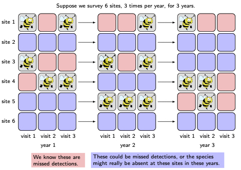

# Possible extinction

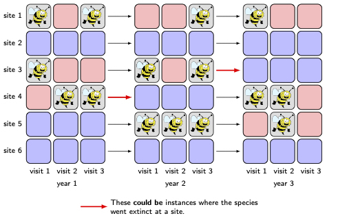

# Observed persistence

[figure not shown]

# Possible colonization

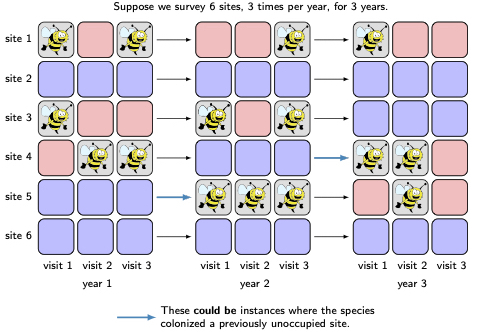

# Single species multi season occupancy

$\mbox{logit}(\psi_{i,j+1}) = \phi_{j} * z_{i,k} + \gamma_{j} * (1-z_{i,j})$.

- $\psi_{i,j}$ is the occupancy probability at the $i^{\mathrm{th}}$ site in the $j^{\mathrm{th}}$ year.
- $\phi_{j}$ denotes the probability the species persists at a site from years $j$ to $j+1$ (given that $z_{i,j}=1$)
- $\gamma_{j}$ denotes the probability that site $i$ is colonized in year $j+1$ (given that $z_{i,j}=0$).

## Simulate the data

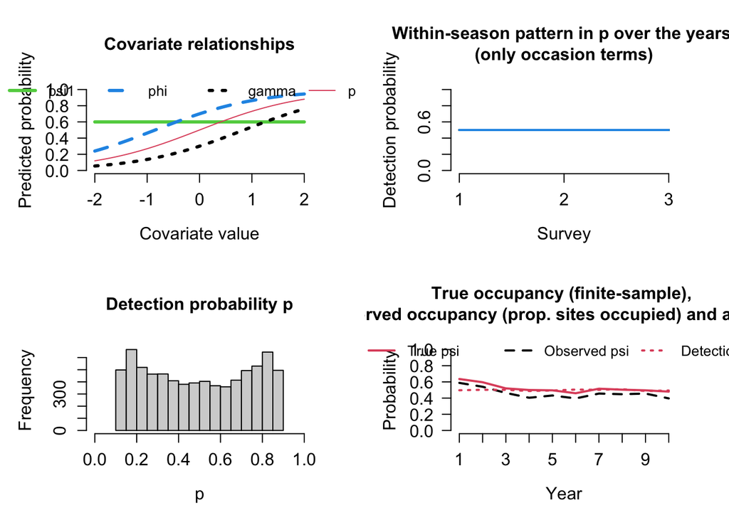

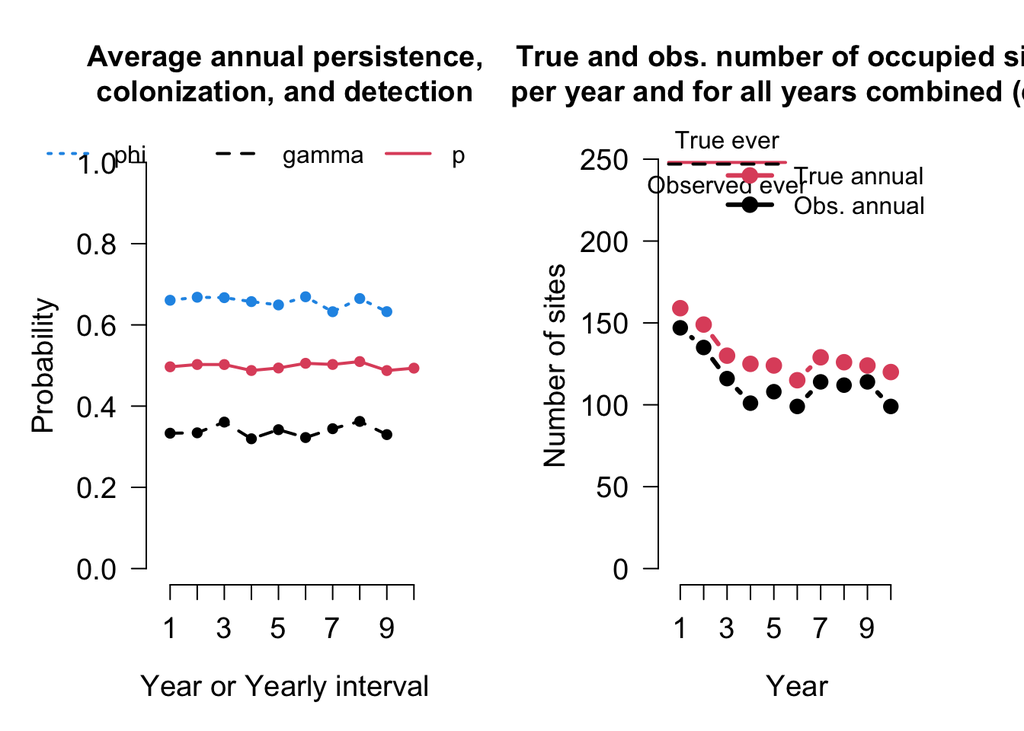

```r
set.seed(444)

# simulate a time-constant model with 3 different covariates affecting the 3 parameters (phi, gamma, p)

occ.data <- AHMbook::simDynocc(
  nsites = 250,
  nyears = 10,
  nsurveys = 3,
  mean.psi1 = 0.6, # average occupancy probability in first year
  beta.Xpsi1 = 0, # coefficient of environ covariate in p(initial occupancy).
  range.phi = c(0.7, 0.7), # bounds of uniform distribution from which annual p(persistence) is randomly drawn.
  beta.Xphi = 1, # coefficients of environ covariate in p(persistence).
  range.gamma = c(0.3, 0.3), # bounds of uniform distribution from which annual p(colonization) is randomly drawn.
  beta.Xgamma = 1, # coefficient of environmental covariate in p(colonization).
  range.p = c(0.5, 0.5), # bounds of uniform distribution from which annual p(detection) is randomly drawn.
  beta.Xp = 1, # coefficient of environmental covariate in p(detection).
  show.plot = TRUE)
```

```r
names(occ.data)
```

```
##  [1] "nsites"               "nyears"               "nsurveys"
##  [4] "year.of.impact"       "impact"               "mean.psi1"
##  [7] "beta.Xpsi1"           "range.phi"            "sd.lphi.site"
## [10] "impact.phi"           "beta.Xphi"            "BACI.effect.phi"
## [13] "range.gamma"          "sd.lgamma.site"       "impact.gamma"
## [16] "beta.Xgamma"          "sd.lphi.lgamma.site"  "BACI.effect.gamma"
## [19] "range.p"              "beta.Xp"              "trend.sd.site"
## [22] "trend.sd.survey"      "range.beta1.survey"   "range.beta2.survey"
## [25] "beta1"                "beta2"                "p.occasion"
## [28] "sd.site"              "sd.survey"            "mean.phi"
## [31] "mean.gamma"           "mean.p"               "avg.phi"
## [34] "avg.gamma"            "avg.p"                "psi"
## [37] "mean.psi"             "n.occ"                "n.occ.ever"
## [40] "n.occ.obs"            "n.occ.ever.obs"       "psi.fs"
## [43] "psi.app"              "z"                    "phi"
## [46] "gamma"                "p"                    "y"
## [49] "Xpsi1"                "Xphi"                 "Xgamma"
## [52] "Xp"                   "eps.lphi.site"        "eps.lgamma.site"
## [55] "eps.lphi.lgamma.site" "eps1"                 "eps2"
## [58] "eps3"
```

```r
dim(occ.data$z)
```

```
## [1] 250  10
```

```r
head(occ.data$z)
```

```
##       Year1 Year2 Year3 Year4 Year5 Year6 Year7 Year8 Year9 Year10
## Site1     0     1     0     0     1     1     0     0     1      1
## Site2     0     0     1     0     0     1     1     0     0      1
## Site3     0     1     1     1     0     0     0     1     0      1
## Site4     1     0     1     1     1     1     1     0     1      0
## Site5     1     1     0     0     1     0     0     0     0      1
## Site6     1     0     1     1     1     0     0     0     0      0
```

# Basic nimble workflow

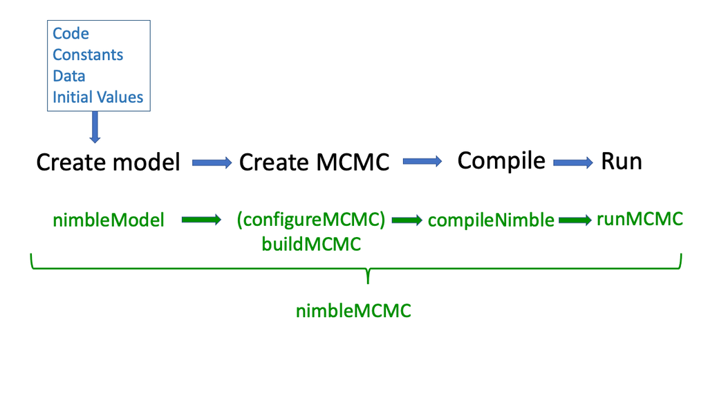

```r
dOcc_code <- nimbleCode({
  for (site in 1:nsite) {
    for (year in 1:nyear) {

      ## persistence
      logit(phi[site, year]) <- beta[1] + beta[2] * Xphi[site, year]

      ## colonization
      logit(gamma[site, year]) <- beta[3] + beta[4] * Xgamma[site, year]

      ## detection
      for (survey in 1:nsurvey) {
        logit(p[site, survey, year]) <- beta[5] + beta[6] * Xp[site, survey, year]
      }
    }

  }

  ## Ecological submodel: Define state conditional on parameters
  for (site in 1:nsite){
    z[site,1] ~ dbern(psi1)
    for (year in 2:nyear){
      logit(muZ[site, year]) <- z[site,year-1]*phi[site, year-1] +
        (1-z[site, year-1])*gamma[site, year-1]
      z[site, year] ~ dbern(muZ[site, year])
    }
    }
  ## Observation model
  for (site in 1:nsite){
    for (survey in 1:nsurvey){
      for (year in 1:nyear){
        muy[site,survey,year] <- z[site,year]*ilogit(p[site, survey, year])
        y[site,survey,year] ~ dbern(muy[site,survey,year])
      }
    }
  }

    # priors
  psi1 ~ dunif(0, 1)
  for (i in 1:6) {
    beta[i] ~ dnorm(0, 1.0e-2)
  }
  })
```

# Setup data, constants, and inits

```r
## data zs with 0s set to NAs
zs <- apply(occ.data$y, c(1, 3), max, na.rm=TRUE)
zs[zs == 0] <- NA

## initial conditions, NAs where 1s in z, and 1s are where NA
zinits <- zs
zinits[zinits == 1] <- 2
zinits[is.na(zinits)] <- sample(0:1, sum(is.na(zinits)),
                                replace=TRUE) ## random 1,0 for unobserved
zinits[zinits == 2] <- NA

head(zinits)
```

```
##       Year1 Year2 Year3 Year4 Year5 Year6 Year7 Year8 Year9 Year10
## Site1     1    NA     1     0     0    NA     1     1     1      1
## Site2     0     1    NA     1     0    NA    NA     1     1     NA
## Site3     0    NA     1    NA     0     0     1    NA     1     NA
## Site4    NA     1    NA    NA    NA    NA    NA     0    NA      1
## Site5     0    NA     0     0    NA     1     1     1     0     NA
## Site6    NA     0    NA    NA    NA     1     1     1     1      0
```

```r
head(zs)
```

```
##       Year1 Year2 Year3 Year4 Year5 Year6 Year7 Year8 Year9 Year10
## Site1    NA     1    NA    NA    NA     1    NA    NA    NA     NA
## Site2    NA    NA     1    NA    NA     1     1    NA    NA      1
## Site3    NA     1    NA     1    NA    NA    NA     1    NA      1
## Site4     1    NA     1     1     1     1     1    NA     1     NA
## Site5    NA     1    NA    NA     1    NA    NA    NA    NA      1
## Site6     1    NA     1     1     1    NA    NA    NA    NA     NA
```

## Compare z an z inits

- Where a species was detected, a 1 is provided in the data. There is no need to set up a sampler to sample this node. This would be wasted computation.
- The same nodes in the inits get an NA because there is no reason to have a initial condition for a node you will not sample -Where it wasn’t detected, NA is provided in the data so nimble knows to sample that note as a latent state

```r
## constants

dOcc_constants <- list(nsite = occ.data$nsites,
                  nsurvey = occ.data$nsurveys,
                  nyear = occ.data$nyears)

## data
dOcc_data <- list(y = occ.data$y,
                  z = zs,
                  Xphi = occ.data$Xphi,
                  Xgamma = occ.data$Xgamma,
                  Xp = occ.data$Xp)

## initial conditions
dOcc_inits <- list(z = zinits,
                  psi1 = runif(1, 0, 1),
                  beta = runif(6, -2, 2))
```

# What are constants? What are data?

### Constants are values needed to define model relationships

- Index starting/ending values like `N`
- Constant indexing vectors for indexing data groupings (site, treatment, individual, time): `beta[ treatment[i] ]`.
- Constants must be provided when creating a model with `nimbleModel`.

### Data represents a flag on the role a node plays in the model

- E.g., data nodes shouldn’t be sampled in MCMC.
- Data *values* can be changed.
- Data can be provided when calling `nimbleModel` or later.

### Providing data and constants together.

- Data and constants can be provided together **as `constants`**.
- It would be slightly easier for BUGS/JAGS users to call this “data”, but that would blur the concepts.
- NIMBLE will usually disambiguate data and constants when they are provided together as `constants`.

### What are covariates and other non-parameters/non-observations?

- Covariates/predictors are neither parameters nor data in the sense of the likelihood.
- Covariates/predictors can be provided via `constants` if you don’t need to change them (often the case).
- Covariates/predictors can be provided via `data` or `inits` if you want to change them.
  - NIMBLE will not treat them as ‘data nodes’.

# Create a model

```r
dOcc_model <- nimbleModel(code = dOcc_code,
                          constants = dOcc_constants,
                          data = dOcc_data,     # data can be set later.
                          inits = dOcc_inits  # inits can be set later.
                          )
```

```
## Defining model
```

```
## Building model
```

```
## Setting data and initial values
```

```
## Running calculate on model
##   [Note] Any error reports that follow may simply reflect missing values in model variables.
```

```
## Checking model sizes and dimensions
```

```
##   [Note] This model is not fully initialized. This is not an error.
##          To see which variables are not initialized, use model$initializeInfo().
##          For more information on model initialization, see help(modelInitialization).
```

```r
dOcc_model$initializeInfo()
```

```
##   [Note] Missing values (NAs) or non-finite values were found in model variables: muZ.
##   [Note] This is not an error, but some or all variables may need to be initialized for certain algorithms to operate properly.
##   [Note] For more information on model initialization, see help(modelInitialization).
```

# Create an MCMC

```r
dOcc_MCMCconf <- configureMCMC(dOcc_model) # defaults to top-level parameters
```

```
## ===== Monitors =====
## thin = 1: beta, psi1
## ===== Samplers =====
## RW sampler (7)
##   - psi1
##   - beta[]  (6 elements)
## binary sampler (1355)
##   - z[]  (1355 elements)
```

```r
dOcc_MCMC <- buildMCMC(dOcc_MCMCconf)
```

# Compile the model and MCMC

## 3. Compile the model and MCMC

```r
C_dOcc_model <- compileNimble(dOcc_model) # These two lines can be done in one line.
```

```
## Compiling
##   [Note] This may take a minute.
##   [Note] Use 'showCompilerOutput = TRUE' to see C++ compilation details.
```

```r
C_dOcc_MCMC <- compileNimble(dOcc_MCMC, project = dOcc_model)
```

```
## Compiling
##   [Note] This may take a minute.
##   [Note] Use 'showCompilerOutput = TRUE' to see C++ compilation details.
```

## 4. Run the MCMC

```r
samples <- runMCMC(C_dOcc_MCMC, niter = 10000,
                   samplesAsCodaMCMC = TRUE,
                   nchains=3,
                   nburnin=1000)
```

```
## Running chain 1 ...
```

```
## |-------------|-------------|-------------|-------------|
## |-------------------------------------------------------|
```

```
## Running chain 2 ...
```

```
## |-------------|-------------|-------------|-------------|
## |-------------------------------------------------------|
```

```
## Running chain 3 ...
```

```
## |-------------|-------------|-------------|-------------|
## |-------------------------------------------------------|
```

```r
# Alternative:
# C_dOcc_MCMC$run(1000)
# samples <- as.matrix(C_dOcc_MCMC$mvSamples)
summary(samples)
```

```
##
## Iterations = 1:9000
## Thinning interval = 1
## Number of chains = 3
## Sample size per chain = 9000
##
## 1. Empirical mean and standard deviation for each variable,
##    plus standard error of the mean:
##
##             Mean      SD  Naive SE Time-series SE
## beta[1]   0.4402 1.35606 0.0082527      0.0209765
## beta[2]  14.1989 5.87308 0.0357424      0.0963898
## beta[3] -10.5329 4.51913 0.0275025      0.3830171
## beta[4]   7.9148 3.40502 0.0207223      0.2706360
## beta[5]  -5.6556 2.09927 0.0127758      0.1160831
## beta[6]  11.6095 4.25430 0.0258909      0.2357994
## psi1      0.6305 0.03317 0.0002018      0.0004724
##
## 2. Quantiles for each variable:
##
##             2.5%      25%     50%     75%   97.5%
## beta[1]  -2.0991  -0.4035  0.3695  1.2005  3.4060
## beta[2]   5.4020   9.7877 13.3891 17.7183 27.6760
## beta[3] -20.8483 -13.1690 -9.7664 -7.0370 -4.1754
## beta[4]   2.9441   5.3331  7.3598 10.0167 15.4404
## beta[5] -10.9656  -6.6873 -5.2447 -4.1192 -2.8457
## beta[6]   5.9382   8.5133 10.7161 13.6365 22.2956
## psi1      0.5637   0.6087  0.6310  0.6524  0.6948
```

[figure not shown]

[figure not shown]

```r
plot(samples)
```

# How can I use the model in R?

```r
class(dOcc_model)[1]  # This is a reference class (S5) object
```

```
## [1] "dOcc_code_MID_1_modelClass_UID_2_UID_3"
```

```r
dOcc_model$gamma           # Look at a model variable,
```

```
##             [,1]      [,2]      [,3]      [,4]      [,5]      [,6]      [,7]
##   [1,] 0.8402582 0.7719544 0.8658484 0.8573434 0.7560256 0.7742467 0.7745288
##   [2,] 0.7534626 0.8202630 0.8068562 0.8172316 0.8298031 0.8478109 0.8062798
##   [3,] 0.7631304 0.8458087 0.8388067 0.8115556 0.7742611 0.7578114 0.8116732
##   [4,] 0.7594075 0.8637940 0.7772881 0.7565637 0.7550442 0.7539273 0.8050954
##   [5,] 0.7663383 0.8392451 0.8249948 0.7955614 0.7782601 0.7836415 0.8522820
##   [6,] 0.7790938 0.8670251 0.8067410 0.7917568 0.7574987 0.8071121 0.8655947
##   [7,] 0.7628669 0.8677903 0.8415712 0.7953097 0.8145287 0.8184849 0.8084963
##   [8,] 0.7995426 0.8487059 0.8507732 0.8508245 0.8047700 0.8155713 0.8174484
##   [9,] 0.7621099 0.8018870 0.8265073 0.8589390 0.7983122 0.8171138 0.7888411
##  [10,] 0.8672133 0.8080525 0.8283504 0.8235596 0.8492988 0.8064159 0.8232805
##  [11,] 0.7977035 0.8584513 0.7812661 0.8120108 0.8079246 0.8088762 0.8349167
##  [12,] 0.7841527 0.7848223 0.7839405 0.8675295 0.8531337 0.8664043 0.8225641
##  [13,] 0.8431274 0.8472250 0.8681285 0.8003248 0.8190174 0.7878623 0.7892773
##  [14,] 0.8169302 0.8510516 0.8452719 0.8656611 0.7576318 0.8196050 0.8278362
```

[output cut: 487 more lines]

```r
dOcc_model$y[1:2,, ]        # or part of one.
```

```
## , , Year1
##
##       Visit1 Visit2 Visit3
## Site1      0      0      0
## Site2      0      0      0
##
## , , Year2
##
##       Visit1 Visit2 Visit3
## Site1      1      0      0
## Site2      0      0      0
##
## , , Year3
##
##       Visit1 Visit2 Visit3
## Site1      0      0      0
## Site2      1      1      1
##
## , , Year4
##
##       Visit1 Visit2 Visit3
## Site1      0      0      0
## Site2      0      0      0
##
## , , Year5
##
##       Visit1 Visit2 Visit3
## Site1      0      0      0
## Site2      0      0      0
##
## , , Year6
##
##       Visit1 Visit2 Visit3
## Site1      1      1      1
## Site2      1      0      1
##
## , , Year7
##
##       Visit1 Visit2 Visit3
## Site1      0      0      0
## Site2      0      1      0
##
## , , Year8
##
##       Visit1 Visit2 Visit3
## Site1      0      0      0
## Site2      0      0      0
##
## , , Year9
##
##       Visit1 Visit2 Visit3
## Site1      0      0      0
## Site2      0      0      0
##
## , , Year10
##
##       Visit1 Visit2 Visit3
## Site1      0      0      0
## Site2      1      0      0
```

```r
dOcc_model$isData('gamma') # Query what is data
```

```
##    [1] FALSE FALSE FALSE FALSE FALSE FALSE FALSE FALSE FALSE FALSE FALSE FALSE
##   [13] FALSE FALSE FALSE FALSE FALSE FALSE FALSE FALSE FALSE FALSE FALSE FALSE
##   [25] FALSE FALSE FALSE FALSE FALSE FALSE FALSE FALSE FALSE FALSE FALSE FALSE
##   [37] FALSE FALSE FALSE FALSE FALSE FALSE FALSE FALSE FALSE FALSE FALSE FALSE
##   [49] FALSE FALSE FALSE FALSE FALSE FALSE FALSE FALSE FALSE FALSE FALSE FALSE
##   [61] FALSE FALSE FALSE FALSE FALSE FALSE FALSE FALSE FALSE FALSE FALSE FALSE
##   [73] FALSE FALSE FALSE FALSE FALSE FALSE FALSE FALSE FALSE FALSE FALSE FALSE
##   [85] FALSE FALSE FALSE FALSE FALSE FALSE FALSE FALSE FALSE FALSE FALSE FALSE
##   [97] FALSE FALSE FALSE FALSE FALSE FALSE FALSE FALSE FALSE FALSE FALSE FALSE
##  [109] FALSE FALSE FALSE FALSE FALSE FALSE FALSE FALSE FALSE FALSE FALSE FALSE
##  [121] FALSE FALSE FALSE FALSE FALSE FALSE FALSE FALSE FALSE FALSE FALSE FALSE
##  [133] FALSE FALSE FALSE FALSE FALSE FALSE FALSE FALSE FALSE FALSE FALSE FALSE
##  [145] FALSE FALSE FALSE FALSE FALSE FALSE FALSE FALSE FALSE FALSE FALSE FALSE
##  [157] FALSE FALSE FALSE FALSE FALSE FALSE FALSE FALSE FALSE FALSE FALSE FALSE
##  [169] FALSE FALSE FALSE FALSE FALSE FALSE FALSE FALSE FALSE FALSE FALSE FALSE
```

[output cut: 194 more lines]

```r
dOcc_model$getNodeNames()[1:10]  # Query what are the nodes (vertices) in the graph,
```

```
##  [1] "psi1"    "beta[1]" "beta[2]" "beta[3]" "beta[4]" "beta[5]" "beta[6]"
##  [8] "z[1, 1]" "z[2, 1]" "z[3, 1]"
```

```r
dOcc_model$getDependencies("z[1, 3]") # and what depends on what..
```

```
## [1] "z[1, 3]"      "muZ[1, 4]"    "muy[1, 1, 3]" "muy[1, 2, 3]" "muy[1, 3, 3]"
## [6] "z[1, 4]"      "y[1, 1, 3]"   "y[1, 2, 3]"   "y[1, 3, 3]"
```

```r
dOcc_model$calculate()     # Calculate the entire model. Return sum of log probabilities.
```

```
## [1] -6448.171
```

```r
dOcc_model$calculate('z[1, 3]') # Calculate one or more nodes in the model.
```

```
## [1] -0.3386153
```

```r
dOcc_model$calculate(dOcc_model$getDependencies('z[1, 3]')) # Calculate based on model structure.
```

```
## [1] -4.613785
```

```r
dOcc_model$simulate("y", includeData = TRUE) # Simulate new data
head(dOcc_model$y)
```

```
## , , Year1
##
##       Visit1 Visit2 Visit3
## Site1      1      1      1
## Site2      0      0      0
## Site3      0      0      0
## Site4      1      0      0
## Site5      0      0      0
## Site6      0      1      1
##
## , , Year2
##
##       Visit1 Visit2 Visit3
## Site1      0      0      1
## Site2      1      1      1
## Site3      0      1      1
## Site4      1      1      0
## Site5      0      0      1
## Site6      0      0      0
##
## , , Year3
##
##       Visit1 Visit2 Visit3
## Site1      0      1      0
## Site2      1      1      0
## Site3      0      0      1
## Site4      1      1      0
## Site5      0      0      0
## Site6      1      0      1
##
## , , Year4
##
##       Visit1 Visit2 Visit3
## Site1      0      0      0
## Site2      0      1      1
## Site3      1      0      1
## Site4      1      1      1
## Site5      0      0      0
## Site6      0      0      1
##
```

[output cut: 44 more lines]

```
## Site2      1      0      0
## Site3      1      1      1
## Site4      1      0      1
## Site5      0      0      0
## Site6      0      1      1
##
## , , Year10
##
##       Visit1 Visit2 Visit3
## Site1      1      0      1
## Site2      1      1      1
## Site3      1      1      1
## Site4      1      1      1
## Site5      1      1      0
## Site6      0      0      0
```

```r
dOcc_model$calculate("y")   # Calculate new sum of log probabilities
```

```
## [1] -3450.67
```

```r
C_dOcc_model$y <- dOcc_model$y # The compiled model can be used in the same way
C_dOcc_model$calculate()
```

```
## [1] -Inf
```

# Differences from NIMBLE to JAGS and/or BUGS

- See our [guide on converting from JAGS to NIMBLE](https://r-nimble.org/quick-guide-for-converting-from-jags-or-bugs-to-nimble)
- Wrap your model code in `nimbleCode({})` directly in R.
- Provide information about missing or empty indices:
  - Use `x[1:n, 1:m]` or
  - `x[,]` with `dimensions = list(x = c(n,m))`.
  - Do not use `x` without brackets (unless it is a scalar).
- Decide how much control you need:
  - `nimbleMCMC` will do everything.
  - `nimbleModel`, `configureMCMC`, `buildMCMC`, `compileNimble` and `runMCMC` give you more control.